# EstComp-Tarea09

Los datos beauty consisten en evaluaciones de estudiantes a profesores, los estudiantes calificaron belleza y calidad de enseñanza para distintos cursos en la Universidad de Texas. Las evaluaciones de curso se realizaron al final del semestre y tiempo después 6 estudiantes que no llevaron el curso realizaron los juicios de belleza. Ajusta un modelo de regresión lineal usando las variables *edad* (age), *belleza* (btystdave), *sexo* (female) e *inglés no es primera lengua* (nonenglish) para predecir las evaluaciones del curso (courseevaluation) .

```r
beauty <- read.csv("beauty.csv")
fit_score <- lm(courseevaluation ~ age + btystdave + female + nonenglish,
                data = beauty)
```

1. La instructora A es una mujer de 50 años, el inglés es su primera lengua y tiene un puntaje de belleza de -1. El instructor B es un hombre de 60 años, su primera lengua es el inglés y tiene un puntaje de belleza de -0.5. Simula 1000 generaciones de la evaluación del curso de estos dos instructores. En tus simulaciones debes incorporar la incertidumbre en los parámetros y en la predicción.

Para hacer las simulaciones necesitarás la distribución del vector de coeficientes $\beta$, este es normal con media:

```r
coef(fit_score)
```

```
#> (Intercept)         age   btystdave      female  nonenglish
#>     4.24446    -0.00259     0.14103    -0.21030    -0.33223
```

y matriz de varianzas y covarianzas $\sigma^2 V$, donde $V$ es:

```r
summary(fit_score)$cov.unscaled
```

```
#>             (Intercept)       age btystdave    female nonenglish
#> (Intercept)     0.07076 -1.33e-03 -3.79e-03 -1.05e-02  -2.20e-03
#> age            -0.00133  2.65e-05  8.78e-05  1.32e-04  -1.79e-06
#> btystdave      -0.00379  8.78e-05  3.83e-03 -2.71e-04  -1.21e-04
#> female         -0.01049  1.32e-04 -2.71e-04  9.66e-03  -5.58e-05
#> nonenglish     -0.00220 -1.79e-06 -1.21e-04 -5.58e-05   3.80e-02
```

y $\sigma$ se calcula como $\sigma=\hat{\sigma}\sqrt{(df)/X}$, donde X es una generación de una distribución $\chi ^2$ con $df$ (458) grados de libertad $\hat{\sigma}$ es:

```r
summary(fit_score)$sigma
```

```
#> [1] 0.532
```

y $df$ (los grados de libertad) se obtienen:

```r
summary(fit_score)$df[2]
```

```
#> [1] 458
```

```r
library(dplyr)
#instructora A
instA<-beauty%>%filter(age==50 & nonenglish==0 & female==1 & round(btystdave)==-1)
instB<-beauty%>%filter(age==60 & nonenglish==0 & female==0 & round(btystdave,digits=1)==-0.5)
instA
```

[output not shown]

[output cut: 65 more lines]

**Ejercicio 1** Una vez que obtengas una simulación del vector $\beta$ generas simulaciones para los profesores usando el modelo de regresión lineal y las imulaciones de los parámetros.

- Realiza un histograma de la diferencia entre la evaluación del curso para A y B.

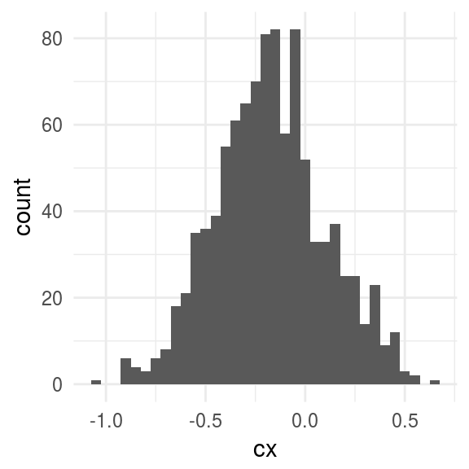

```r
#simulamos
sig<-summary(fit_score)$sigma
SIG<-summary(fit_score)$cov.unscaled
simula_parametros <- function(){
    # empezamos simulando sigma
    sigma <- sig * sqrt((458) / rchisq(1, 458))
    # la usamos para simular betas-0.002585912  0.141031893 -0.210304324 -0.332233708
    beta <- MASS::mvrnorm(1, mu = c(4.244464824,-0.0025859,0.141031893,-0.210304324,-0.332233708),
        # Sigma
        Sigma = sig ^ 2 * SIG)
    # Simulamos las observaciones
    list(sigma = sigma, beta = beta)
}

sims_parametros <- rerun(1000, simula_parametros())

# simulamos los puntajes
simula_puntajes <- function(beta, sigma, A = 7, B =8){
    vector_mu <- c(rep(beta[1] + beta[2]+beta[3] + beta[4], A), rep(beta[1] + beta[2]+beta[3], B)) # beta_0 + beta_1*X1+beta_2*X2 + beta_3*X3+beta_4*X4
    obs = rnorm(15, vector_mu, sigma)
}

sims_puntajes <- map(sims_parametros, ~simula_puntajes(beta = .[["beta"]], sigma = .[["sigma"]]))
medias_incert <- sims_puntajes %>% map_dbl(mean)

#hacemos u vector de diferencia de los promedios de las calificaciones...
cx<-rep(0,1000)

for (i in 1:1000){
cx[i]<-mean(sims_puntajes[[i]][1:8])-mean(sims_puntajes[[i]][9:15])
#sims_puntajes
}

#Histograma de difrencias de A y B
ggplot(data=NULL,aes(x=cx))+geom_histogram(binwidth =.05)
```

- ¿Cuál es la probabilidad de que A obtenga una calificación mayor?

```r
#cx es el vector de diferencias de calificaciones si son negativos entonces A es mejor calificado..
cf<-function(x){
  if(x<0){
    return(1)
  }
  else{
    return(0)
  }
}

f<-rep(0,1000)
for(i in 1:1000){
  f[i]<-cf(cx[i])
}

#proba de que A salga mejor..
mean(f)
```

```
#> [1] 0.758
```

2. En el inciso anterior obtienes simulaciones de la distribución conjunta $p(\tilde{y},\beta,\sigma^2)$ donde $\beta$ es el vector de coeficientes de la regresión lineal. Para este ejercicio nos vamos a enfocar en el coeficiente de belleza ($\beta_3$), realiza 6000 simulaciones del modelo (como en el inciso anterior) y guarda las realizaciones de $\beta_3$.

```r
#simulamos
sig<-summary(fit_score)$sigma
SIG<-summary(fit_score)$cov.unscaled
simula_parametros <- function(){
    # empezamos simulando sigma
    sigma <- sig * sqrt((458) / rchisq(1, 458))
    # la usamos para simular betas-0.002585912  0.141031893 -0.210304324 -0.332233708
    beta <- MASS::mvrnorm(1, mu = c(4.244464824,-0.0025859,0.141031893,-0.210304324,-0.332233708),
        # Sigma
        Sigma = sig ^ 2 * SIG)
    # Simulamos las observaciones
    list(sigma = sigma, beta = beta)
}

sims_parametros <- rerun(6000, simula_parametros())
b3<-rep(0,6000)
for(i in 1:6000){
b3[i]<-sims_parametros[[i]]$beta[3]
}
```

- Genera un histograma con las simulaciones de $\beta_3$.

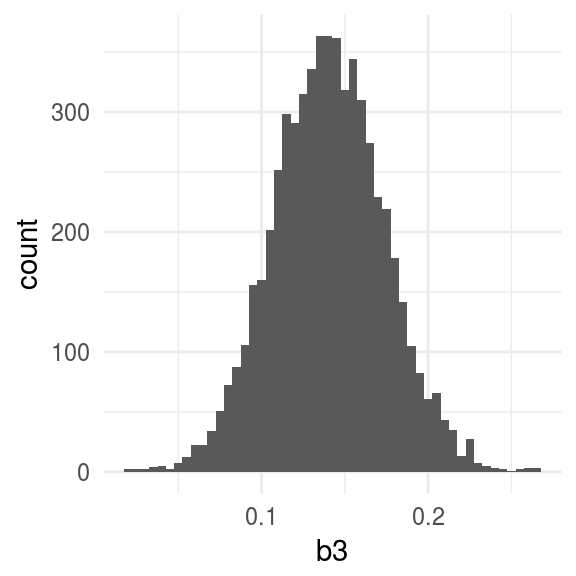

```r
#graficando b3...
ggplot(data=NULL,aes(x=b3))+geom_histogram(binwidth = .005)
```

- Calcula la media y desviación estándar de las simulaciones y comparalas con la estimación y desviación estándar del coeficiente obtenidas usando summary.

```r
#media b3
mean(b3)
```

```
#> [1] 0.14
```

```r
#desv b3
sd(b3)
```

```
#> [1] 0.0333
```

Comaparando con el summary del original enemos que

```r
#media
coef(fit_score)[3]
```

```
#> btystdave
#>     0.141
```

```r
#desviacion...
summary(fit_score)$cov.unscaled[3,3]
```

```
#> [1] 0.00383
```